# Presentes

Alberto Sabá Fernandez Robles y Clara Bonpland Mignaquy

## Introducción

El presente informe consiste en el análisis de los datos del paquete “presentes”, el cual reúne la información oficial sobre víctimas de la última dictadura militar entre el 24 de marzo de 1976 y el 10 de diciembre de 1983 en Argentina, como también de años previos al inicio formal del golpe de estado militar.

Las fuentes principales de los datos del paquete provienen de:

Registro Único de Víctimas del Terrorismo de Estado (RUVTE), dependiente de la Secretaría de Derechos Humanos y Pluralismo Cultural del Ministerio de Justicia y Derechos Humanos de la Nación.

https://datos.gob.ar/dataset/justicia-registro-unificado-victimas-terrorismo-estado--ruvte-

Monumento a las Víctimas del Terrorismo de Estado, realizado por el Consejo de Gestión del Parque de la Memoria y del Monumento a las Víctimas del Terrorismo de Estado, creado por la ley 3078 de la Ciudad de Buenos Aires.

http://basededatos.parquedelamemoria.org.ar/

## Cargamos los datos

```r
victimas_parque <- presentes::parque_de_la_memoria
victimas_apodo <- presentes::apodos
victimas_denuncia <- presentes::victimas_accionar_represivo_ilegal
victimas_sin_denuncia <- presentes::victimas_accionar_represivo_ilegal_sin_denuncia_formal
centros_clandestinos <- presentes::centros_clandestinos_detencion
```

## Exploración de los datos

Consideramos que el primer paso necesario es explorar el paquete para conocer qué variables y observaciones contiene.

Selección de variables de victimas_parque:

```r
victimas_parque <- select(parque_de_la_memoria, id, edad, fecha_de_secuestro, ano_en_monumento, lugar_de_secuestro, ocupaciones, sexo, militancia)
```

Exploramos las especificaciones de victimas_parque. Queremos saber qué contiene.

```r
victimas_parque %>%
  glimpse()
```

```
## Rows: 8,751
## Columns: 8
## $ id                 <chr> "2123", "2125", "50", "2126", "2124", "2129", "2127…
## $ edad               <chr> "26", "24", "23", "25", "54", "23", "23", "25", "27…
## $ fecha_de_secuestro <chr> "02/01/1977", "15/08/1976", "01/07/1976", NA, "04/0…
## $ ano_en_monumento   <chr> "1977", "1976", "1976", "1976", "1975", "1976", "19…
## $ lugar_de_secuestro <chr> "LA PLATA. BS. AS.", "CORDOBA CAPITAL", "CAPITAL FE…
## $ ocupaciones        <chr> "Estudiante Universitario                          …
## $ sexo               <chr> "Masculino", "Femenino", "Masculino", "Masculino", …
## $ militancia         <list> [<tbl_df[0 x 1]>], [<tbl_df[0 x 1]>], [<tbl_df[1 x…
```

El dataframe victimas_parque contiene 8.751 observaciones y 8 variables.

Exploración por sexo de las víctimas.

```r
victimas_parque %>%
  group_by(sexo) %>%
  summarise(cantidad_sexo = n()) %>%
  arrange(desc(cantidad_sexo)) %>%
  rename("Víctimas" = cantidad_sexo, "Sexo" = sexo) %>%
  gt::gt()
```

| Sexo | Víctimas |
| --- | --- |
| Masculino | 6519 |
| Femenino | 2230 |
| NA | 2 |

Exploración por edad de las victimas.

```r
pw_vp <- victimas_parque %>%
  filter(edad != "-") %>%
  group_by(edad = as.numeric(edad)) %>%
  summarise(cantidad = n()) %>%
  arrange(edad) %>%
  rename("Víctimas" = cantidad, "Edad" = edad)
```

Horizontalizamos la tabla de edad.

```r
pw_vp %>%
  pivot_wider(names_from = Edad,
              values_from = Víctimas) %>%
  gt::gt()
```

| 3 | 5 | 6 | 7 | 9 | 13 | 14 | 15 | 16 | 17 | 18 | 19 | 20 | 21 | 22 | 23 | 24 | 25 | 26 | 27 | 28 | 29 | 30 | 31 | 32 | 33 | 34 | 35 | 36 | 37 | … |
| --- | --- | --- | --- | --- | --- | --- | --- | --- | --- | --- | --- | --- | --- | --- | --- | --- | --- | --- | --- | --- | --- | --- | --- | --- | --- | --- | --- | --- | --- | --- |
| 2 | 3 | 1 | 1 | 1 | 1 | 8 | 24 | 55 | 97 | 183 | 271 | 396 | 537 | 614 | 581 | 613 | 537 | 524 | 514 | 438 | 367 | 298 | 275 | 237 | 226 | 169 | 144 | 126 | 119 | … |

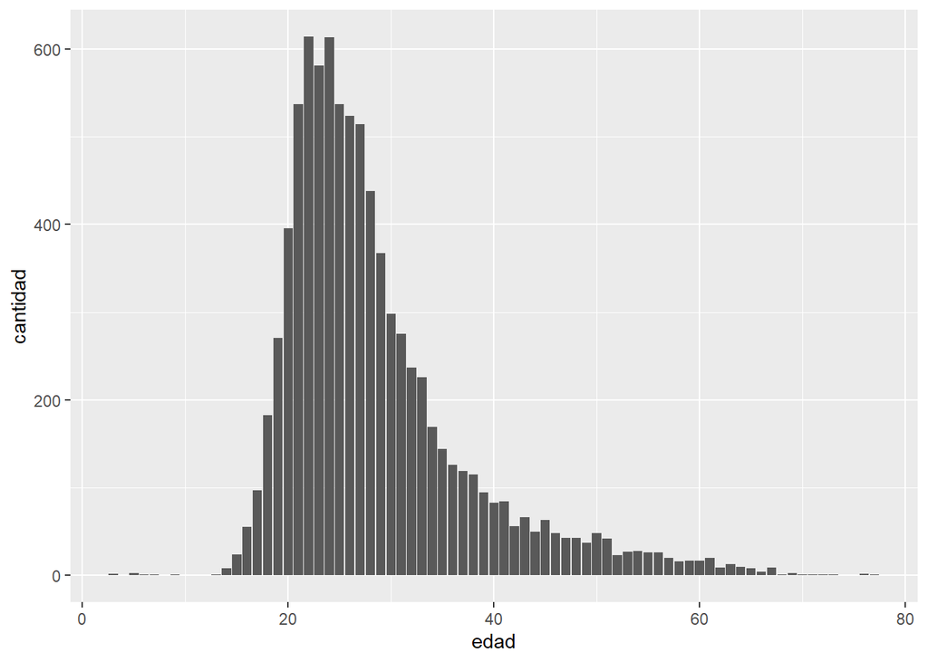

```r
victimas_parque %>%
  group_by(edad = as.numeric(edad)) %>%
  summarise(cantidad = n()) %>%
  arrange(desc(cantidad)) %>%
  ggplot(aes(edad, cantidad)) +
  geom_col()
```

```r
victimas_parque %>%
  mutate(edad = as.numeric(edad)) %>%
  summarise(edad_max = max(edad, na.rm = TRUE),
            edad_min = min(edad, na.rm = TRUE),
            edad_media = mean(edad, na.rm = TRUE),
            edad_sd = sd(edad, na.rm = TRUE)) %>%
  rename("Edad máxima" = edad_max,
         "Edad mínima" = edad_min,
         "Edad media" = edad_media,
         "Desviación estándar" = edad_sd)
```

```
## # A tibble: 1 × 4
##   `Edad máxima` `Edad mínima` `Edad media` `Desviación estándar`
##           <dbl>         <dbl>        <dbl>                 <dbl>
## 1            77             3         28.5                  9.06
```

Filtramos víctimas por edad universitaria.

```r
victimas_parque %>%
  filter(edad %in% c(19:27)) %>%
  group_by(edad) %>%
  summarise(cant_vict_edad = n())  %>%
  rename("Edad" = edad, "Víctimas" = cant_vict_edad) %>%
  gt::gt()
```

| Edad | Víctimas |
| --- | --- |
| 19 | 271 |
| 20 | 396 |
| 21 | 537 |
| 22 | 614 |
| 23 | 581 |
| 24 | 613 |
| 25 | 537 |
| 26 | 524 |
| 27 | 514 |

Nos interesa explorar la variable ocupaciones.

```r
victimas_parque %>%
  group_by(ocupaciones) %>%
  summarise(cant_ocupaciones = n()) %>%
  arrange(desc(cant_ocupaciones)) %>%
  rename("Ocupaciones" = ocupaciones, "Víctimas" = cant_ocupaciones)
```

```
## # A tibble: 3,438 × 2
##    Ocupaciones              Víctimas
##    <chr>                       <int>
##  1 <NA>                         2777
##  2 Estudiante Universitario      577
##  3 Estudiante Universitaria      329
##  4 Estudiante                    138
##  5 Estudiante Secundario          98
##  6 Comerciante                    93
##  7 Abogado                        63
##  8 Albañil                        58
##  9 Jornalero                      55
## 10 Obrero                         51
## # … with 3,428 more rows
```

## Cruce de variables

Nos interesa conocer la cantidad de víctimas por edad y por sexo.

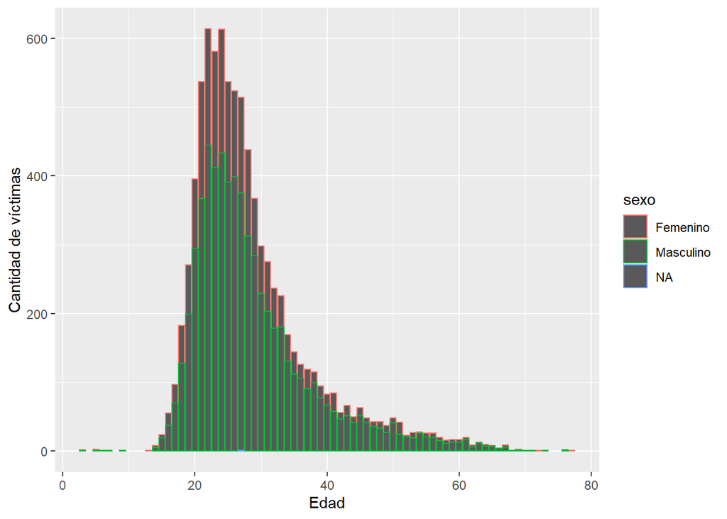

```r
victimas_parque %>%
  filter(edad != "-") %>%
  group_by(edad, sexo) %>%
  mutate(edad = as.numeric(edad)) %>%
  summarise(cantidad = n()) %>%
  arrange(desc(edad)) %>%
  ggplot(aes(edad, cantidad)) +
  geom_col(aes(color = sexo)) +
  xlab("Edad") + ylab("Cantidad de víctimas")
```

También exploramos por edad y ocupaciones de las víctimas.

```r
victimas_parque %>%
  filter(!is.na(ocupaciones)) %>%
  group_by(ocupaciones, edad) %>%
  summarise(cantidad = n()) %>%
  arrange(desc(cantidad))%>%
  rename("Edad" = edad, "Ocupaciones" = ocupaciones, "Víctimas" = cantidad )
```

```
## # A tibble: 4,493 × 3
## # Groups:   Ocupaciones [3,437]
##    Ocupaciones              Edad  Víctimas
##    <chr>                    <chr>    <int>
##  1 Estudiante Universitario 22          89
##  2 Estudiante Universitario 23          69
##  3 Estudiante Universitario 24          67
##  4 Estudiante Universitario 21          66
##  5 Estudiante Universitaria 22          51
##  6 Estudiante Universitario 25          47
##  7 Estudiante Universitario 20          46
##  8 Estudiante Universitaria 21          43
##  9 Estudiante Universitario 26          43
## 10 Estudiante Universitaria 24          42
## # … with 4,483 more rows
```

Del gráfico anterior, nos resultó interesante la cantidad de víctimas con ocupación Estudiante, Estudiante Universitaria/o y Estudiante Secundario.

Exploramos por ocupación y sexo, filtrando las ocupaciones con víctimas mayores a 50 casos. Esta cantidad de casos nos parecen suficientes para observar los resultados que surjan de cruzar variables como ocupación, sexo y militancia.

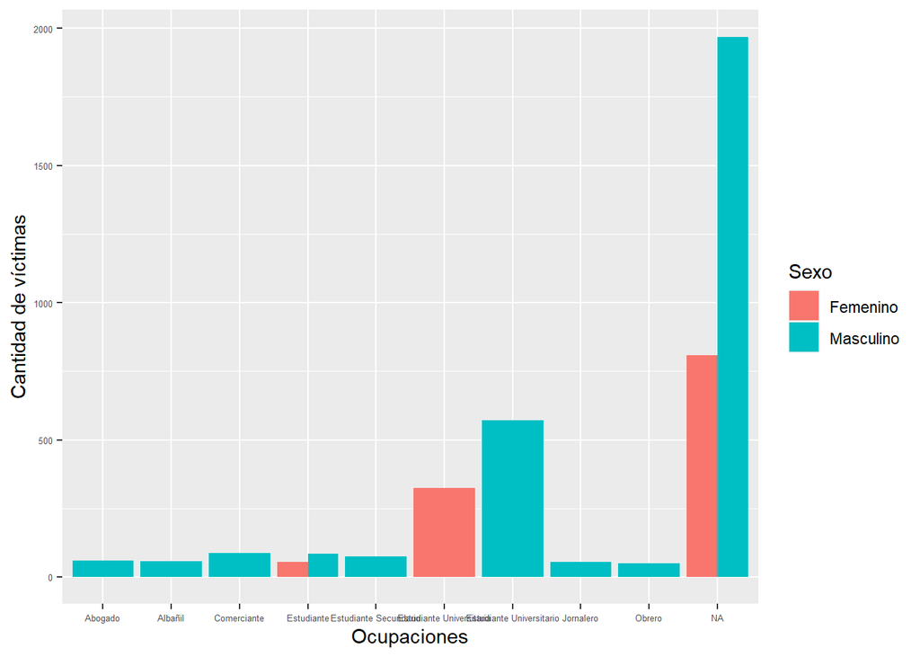

```r
victimas_parque %>%
  group_by(ocupaciones,sexo) %>%
  summarise(cant_ocupaciones = n()) %>%
  arrange(desc(cant_ocupaciones)) %>%
  filter(cant_ocupaciones > 50) %>%
  ggplot(aes(ocupaciones, cant_ocupaciones)) +
  geom_col(aes(fill = sexo), position = "dodge") +
  labs(x = "Ocupaciones", y = "Cantidad de víctimas", fill = "Sexo") +
  theme(axis.text = element_text(size = 5))
```

Eliminamos todos los datos faltantes (NA).

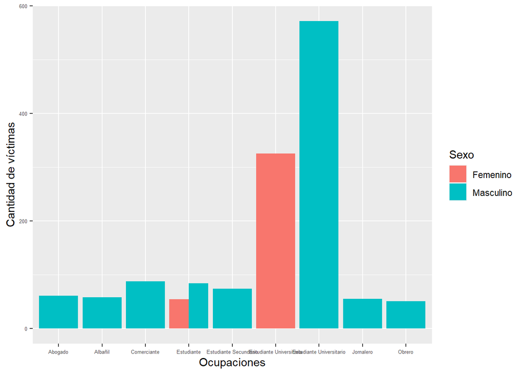

```r
victimas_parque %>%
  filter(!is.na(ocupaciones)) %>%
  group_by(ocupaciones,sexo) %>%
  summarise(cant_ocupaciones = n()) %>%
  arrange(desc(cant_ocupaciones)) %>%
  filter(cant_ocupaciones > 50) %>%
  ggplot(aes(ocupaciones, cant_ocupaciones)) +
  geom_col(aes(fill = sexo), position = "dodge") +
  labs(fill = "Sexo") +
  xlab("Ocupaciones") + ylab("Cantidad de víctimas") +
  theme(axis.text = element_text(size = 5))
```

Queremos saber cuáles fueron los años con mayor cantidad de asesinatos y secuestros.

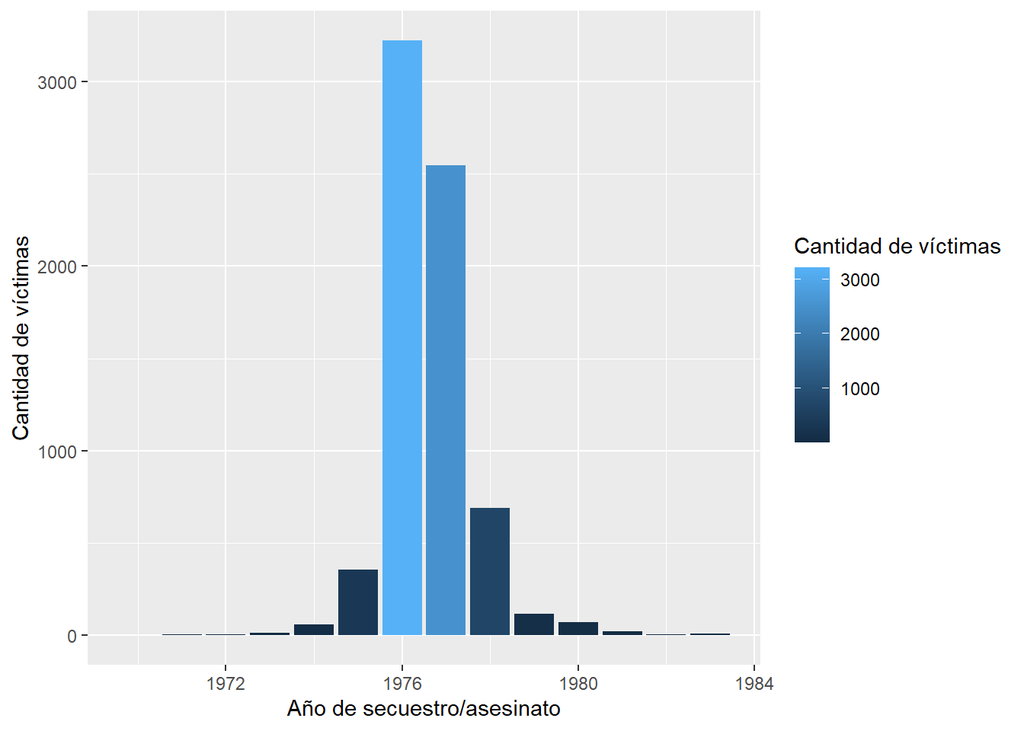

```r
victimas_parque %>%
  group_by(fecha_de_secuestro) %>%
  mutate(fecha = dmy(fecha_de_secuestro)) %>%
  mutate(anio = year(fecha)) %>%
  group_by(anio) %>%
  summarise(victimas_por_anio = n()) %>%
  arrange(desc(victimas_por_anio)) %>%
  ggplot(aes(anio, victimas_por_anio)) +
  geom_col(aes(fill = victimas_por_anio)) +
  labs(fill = "Cantidad de víctimas") +
  xlab("Año de secuestro/asesinato") + ylab("Cantidad de víctimas")
```

Cruzamos la cantidad de víctimas por edad y año de secuestro o asesinato.

```r
victimas_parque %>%
  group_by(fecha_de_secuestro) %>%
  mutate(fecha = dmy(fecha_de_secuestro)) %>%
  mutate(anio = year(fecha)) %>%
  group_by(edad, anio) %>%
  summarise(victimas_por_anio = n()) %>%
  arrange(desc(victimas_por_anio)) %>%
  rename("Edad" = edad, "Año de secuestro/asesinato" = anio, "Víctimas" = victimas_por_anio )
```

```
## # A tibble: 421 × 3
## # Groups:   Edad [69]
##    Edad  `Año de secuestro/asesinato` Víctimas
##    <chr>                        <dbl>    <int>
##  1 22                            1976      255
##  2 21                            1976      233
##  3 23                            1976      228
##  4 24                            1976      221
##  5 25                            1976      199
##  6 22                            1977      197
##  7 27                            1976      194
##  8 24                            1977      187
##  9 23                            1977      171
## 10 26                            1976      169
## # … with 411 more rows
```

Buscamos victimas por edad, año de secuestro y ocupación, dejando de lado la variable sexo.

```r
victimas_parque %>%
  group_by(fecha_de_secuestro) %>%
  mutate(fecha = dmy(fecha_de_secuestro)) %>%
  mutate(anio = year(fecha)) %>%
  group_by(anio, edad, ocupaciones) %>%
  filter(!is.na(ocupaciones)) %>%
  summarise(victimas_por_anio = n()) %>%
  arrange(desc(victimas_por_anio)) %>%
  rename("Edad" = edad, "Año de secuestro/asesinato" = anio, "Ocupaciones" = ocupaciones, "Víctimas" = victimas_por_anio)
```

```
## # A tibble: 4,923 × 4
## # Groups:   Año de secuestro/asesinato, Edad [361]
##    `Año de secuestro/asesinato` Edad  Ocupaciones              Víctimas
##                           <dbl> <chr> <chr>                       <int>
##  1                         1976 22    Estudiante Universitario       37
##  2                         1977 22    Estudiante Universitario       35
##  3                         1976 21    Estudiante Universitario       32
##  4                         1976 24    Estudiante Universitario       31
##  5                         1976 23    Estudiante Universitario       27
##  6                         1977 22    Estudiante Universitaria       23
##  7                         1977 23    Estudiante Universitario       23
##  8                         1976 21    Estudiante Universitaria       21
##  9                         1976 20    Estudiante Universitario       20
## 10                         1976 25    Estudiante Universitario       20
## # … with 4,913 more rows
```

Nos pareció interesante conocer los espacios de militancia de las víctimas. Como la variable de espacios de militancia es una tabla, y una persona puede pertenecer a más de un espacio, tuvimos que desanidar la tabla y explorarla.

```r
militancias <- unnest(victimas_parque, militancia) %>%
  separate(listado, into = c("orga1", "orga2", "orga3", "orga4"), sep =" - ")
```

```r
glimpse(militancias)
```

```
## Rows: 4,156
## Columns: 11
## $ id                 <chr> "50", "2124", "2128", "2128", "245", "2303", "9825"…
## $ edad               <chr> "23", "54", "25", "25", "23", "23", "19", "24", "24…
## $ fecha_de_secuestro <chr> "01/07/1976", "04/05/1975", "06/05/1977", "06/05/19…
## $ ano_en_monumento   <chr> "1976", "1975", "1977", "1977", "1970", "1976", "19…
## $ lugar_de_secuestro <chr> "CAPITAL FEDERAL", "Secuestrado de su domicilio (Sa…
## $ ocupaciones        <chr> NA, "Obrero en Cuerpo Del Dto Gral De Irrigación", …
## $ sexo               <chr> "Masculino", "Masculino", "Masculino", "Masculino",…
## $ orga1              <chr> "Ejército Revolucionario del Pueblo (ERP)", "Partid…
## $ orga2              <chr> NA, "Ejército Revolucionario del Pueblo (PRT-ERP)",…
## $ orga3              <chr> NA, NA, NA, NA, NA, NA, NA, NA, NA, NA, NA, NA, NA,…
## $ orga4              <chr> NA, NA, NA, NA, NA, NA, NA, NA, NA, NA, NA, NA, NA,…
```

Nos interesa conocer la cantidad de víctimas con afiliación a espacios de militancia. Observamos que estos espacios de militancia pueden ser partidarios, de actividad sindical o estudiantil.

```r
 militancias %>%
  group_by(orga1, orga2, orga3, orga4) %>%
  summarise(cant_por_militancia = n()) %>%
  arrange(desc(cant_por_militancia))
```

```
## # A tibble: 413 × 5
## # Groups:   orga1, orga2, orga3 [413]
##    orga1                                            orga2    orga3 orga4 cant_…¹
##    <chr>                                            <chr>    <chr> <chr>   <int>
##  1 Montoneros                                       <NA>     <NA>  <NA>      903
##  2 Partido Revolucionario de los Trabajadores       Ejércit… <NA>  <NA>      429
##  3 Juventud Peronista (JP)                          <NA>     <NA>  <NA>      396
##  4 Juventud Universitaria Peronista (JUP)           <NA>     <NA>  <NA>      278
##  5 Militante sindical                               <NA>     <NA>  <NA>      182
##  6 Partido Comunista Marxista Leninista (PCML)      <NA>     <NA>  <NA>      133
##  7 Partido Revolucionario de los Trabajadores (PRT) <NA>     <NA>  <NA>      129
##  8 Ejército Revolucionario del Pueblo (ERP)         <NA>     <NA>  <NA>      108
##  9 Partido Comunista (PC)                           <NA>     <NA>  <NA>      105
## 10 Partido Socialista de los Trabajadores (PST)     <NA>     <NA>  <NA>       99
## # … with 403 more rows, and abbreviated variable name ¹cant_por_militancia
```

Cruzamos la cantidad de víctimas por espacios de militancia y sus ocupaciones.

```r
militancias %>%
  mutate(fecha = dmy(fecha_de_secuestro)) %>%
  mutate(anio = year(fecha)) %>%
  group_by(ocupaciones, orga1, orga2, orga3, orga4) %>%
  summarise(cant_por_militancia = n()) %>%
  arrange(desc(cant_por_militancia))
```

```
## # A tibble: 2,568 × 6
## # Groups:   ocupaciones, orga1, orga2, orga3 [2,568]
##    ocupaciones              orga1                      orga2 orga3 orga4 cant_…¹
##    <chr>                    <chr>                      <chr> <chr> <chr>   <int>
##  1 <NA>                     Montoneros                 <NA>  <NA>  <NA>      275
##  2 <NA>                     Partido Revolucionario de… Ejér… <NA>  <NA>      151
##  3 Estudiante Universitario Juventud Universitaria Pe… <NA>  <NA>  <NA>       90
##  4 <NA>                     Juventud Peronista (JP)    <NA>  <NA>  <NA>       88
##  5 Estudiante Universitario Montoneros                 <NA>  <NA>  <NA>       78
##  6 Estudiante Universitaria Montoneros                 <NA>  <NA>  <NA>       73
##  7 Estudiante Universitaria Juventud Universitaria Pe… <NA>  <NA>  <NA>       43
##  8 <NA>                     Ejército Revolucionario d… <NA>  <NA>  <NA>       37
##  9 Estudiante Universitaria Partido Revolucionario de… Ejér… <NA>  <NA>       35
## 10 Estudiante Universitario Juventud Peronista (JP)    <NA>  <NA>  <NA>       31
## # … with 2,558 more rows, and abbreviated variable name ¹cant_por_militancia
```

Buscamos cuáles son los espacios de militancia para la ocupación de Estudiantes.

```r
militancias %>%
  mutate(fecha = dmy(fecha_de_secuestro)) %>%
  mutate(anio = year(fecha)) %>%
  group_by(ocupaciones, orga1, orga2, orga3, orga4) %>%
  filter(ocupaciones %in% c("Estudiante Universitario", "Estudiante Universitaria", "Estudiante", "Estudiante Secundario")) %>%
  summarise(cant_por_militancia = n()) %>%
  arrange(desc(cant_por_militancia))
```

```
## # A tibble: 124 × 6
## # Groups:   ocupaciones, orga1, orga2, orga3 [124]
##    ocupaciones              orga1                      orga2 orga3 orga4 cant_…¹
##    <chr>                    <chr>                      <chr> <chr> <chr>   <int>
##  1 Estudiante Universitario Juventud Universitaria Pe… <NA>  <NA>  <NA>       90
##  2 Estudiante Universitario Montoneros                 <NA>  <NA>  <NA>       78
##  3 Estudiante Universitaria Montoneros                 <NA>  <NA>  <NA>       73
##  4 Estudiante Universitaria Juventud Universitaria Pe… <NA>  <NA>  <NA>       43
##  5 Estudiante Universitaria Partido Revolucionario de… Ejér… <NA>  <NA>       35
##  6 Estudiante Universitario Juventud Peronista (JP)    <NA>  <NA>  <NA>       31
##  7 Estudiante Secundario    Unión de Estudiantes Secu… <NA>  <NA>  <NA>       24
##  8 Estudiante Universitario Partido Revolucionario de… Ejér… <NA>  <NA>       23
##  9 Estudiante               Montoneros                 <NA>  <NA>  <NA>       14
## 10 Estudiante Universitario Federación Juvenil Comuni… <NA>  <NA>  <NA>       13
## # … with 114 more rows, and abbreviated variable name ¹cant_por_militancia
```

También queremos conocer los lugares en que ocurrieron los secuestros o detenciones de las víctimas.

```r
victimas_parque %>%
  group_by(fecha_de_secuestro) %>%
  mutate(fecha = dmy(fecha_de_secuestro)) %>%
  mutate(anio = year(fecha)) %>%
  filter(anio %in% c(1976:1982)) %>%
  group_by(lugar_de_secuestro) %>%
  filter(!is.na(lugar_de_secuestro)) %>%
  summarise(cantidad_lugar = n()) %>%
  arrange(desc(cantidad_lugar)) %>%
  rename("Lugar de secuestro" = lugar_de_secuestro, "Víctimas" = cantidad_lugar)
```

```
## # A tibble: 1,348 × 2
##    `Lugar de secuestro`   Víctimas
##    <chr>                     <int>
##  1 CAPITAL FEDERAL            1302
##  2 LA PLATA. BS. AS.           424
##  3 CORDOBA CAPITAL             288
##  4 SAN MIGUEL DE TUCUMAN       194
##  5 ROSARIO. SANTA FE           186
##  6 MAR DEL PLATA. BS. AS.      181
##  7 BUENOS AIRES                148
##  8 CORDOBA                     120
##  9 LANUS. BS. AS.               65
## 10 AVELLANEDA. BS. AS.          55
## # … with 1,338 more rows
```

Resulta interesante que la ciudad de Mar de Plata se encuentra en 6° lugar de la tabla, por lo que buscamos las ocupaciones de las víctimas en el lugar. De acuerdo a lo explorado, nos resulta signifitiva la variable identitaria de estudiante. Cuando exploramos los lugares de secuestro, pensamos en las ciudades como universitarias. Nos llama la atención que Mar del Plata esté en el sexto lugar de mayor cantidad de victimas, porque no consideramos que sea una ciudad universitaria.

Buscamos qué ocupaciones tienen las víctimas.

```r
victimas_parque %>%
  group_by(fecha_de_secuestro) %>%
  mutate(fecha = dmy(fecha_de_secuestro)) %>%
  mutate(anio = year(fecha)) %>%
  filter(anio %in% c(1976:1982)) %>%
  filter(!is.na(lugar_de_secuestro)) %>%
  group_by(lugar_de_secuestro, ocupaciones) %>%
  filter(lugar_de_secuestro == "MAR DEL PLATA. BS. AS.") %>%
  summarise(cantidad_lugar = n()) %>%
  arrange(desc(cantidad_lugar)) %>%
  rename("Lugar de secuestro" = lugar_de_secuestro, "Ocupaciones" = ocupaciones, "Víctimas" = cantidad_lugar)
```

```
## # A tibble: 107 × 3
## # Groups:   Lugar de secuestro [1]
##    `Lugar de secuestro`   Ocupaciones               Víctimas
##    <chr>                  <chr>                        <int>
##  1 MAR DEL PLATA. BS. AS. <NA>                            48
##  2 MAR DEL PLATA. BS. AS. Estudiante Universitaria        10
##  3 MAR DEL PLATA. BS. AS. Estudiante Universitario         9
##  4 MAR DEL PLATA. BS. AS. Albañil                          3
##  5 MAR DEL PLATA. BS. AS. Empleado                         3
##  6 MAR DEL PLATA. BS. AS. Estudiante                       3
##  7 MAR DEL PLATA. BS. AS. Abogado                          2
##  8 MAR DEL PLATA. BS. AS. Comerciante                      2
##  9 MAR DEL PLATA. BS. AS. Obrero                           2
## 10 MAR DEL PLATA. BS. AS. Obrero De La Construcción        2
## # … with 97 more rows
```

Analizamos la cantidad de víctimas con ocupación Estudiante.

```r
victimas_parque %>%
  group_by(fecha_de_secuestro) %>%
  mutate(fecha = dmy(fecha_de_secuestro)) %>%
  mutate(anio = year(fecha)) %>%
  filter(anio %in% c(1976:1982)) %>%
  filter(!is.na(lugar_de_secuestro)) %>%
  group_by(lugar_de_secuestro, ocupaciones) %>%
  filter(lugar_de_secuestro == "MAR DEL PLATA. BS. AS.") %>%
  filter(ocupaciones %in% c("Estudiante Universitario", "Estudiante Universitaria", "Estudiante", "Estudiante Secundario")) %>%
  summarise(cantidad_lugar = n()) %>%
  arrange(desc(cantidad_lugar))
```

```
## # A tibble: 4 × 3
## # Groups:   lugar_de_secuestro [1]
##   lugar_de_secuestro     ocupaciones              cantidad_lugar
##   <chr>                  <chr>                             <int>
## 1 MAR DEL PLATA. BS. AS. Estudiante Universitaria             10
## 2 MAR DEL PLATA. BS. AS. Estudiante Universitario              9
## 3 MAR DEL PLATA. BS. AS. Estudiante                            3
## 4 MAR DEL PLATA. BS. AS. Estudiante Secundario                 1
```

Como pusimos el foco en los estudiantes y no nos parece significativa la cantidad de victimas estudiantes, decidimos filtrar por espacios de militancia.

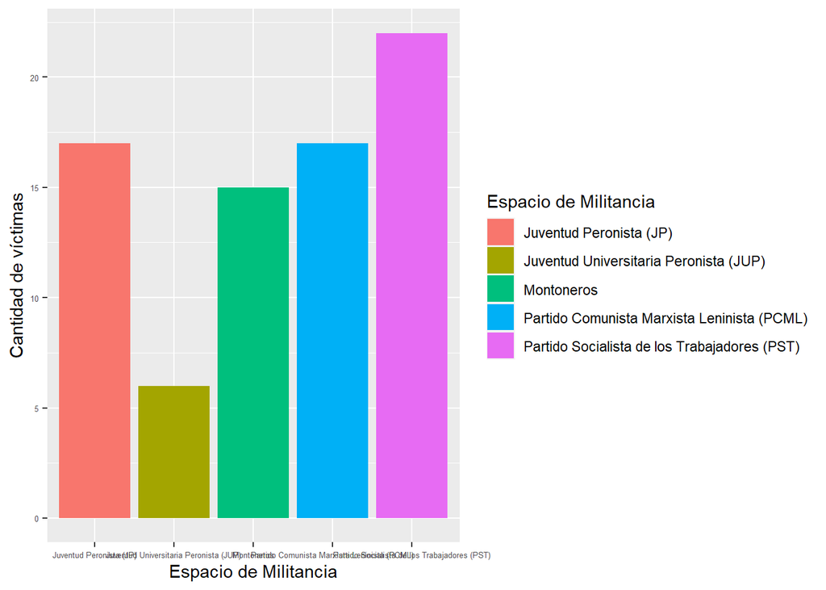

```r
militancias %>%
  group_by(lugar_de_secuestro, orga1) %>%
  filter(lugar_de_secuestro == "MAR DEL PLATA. BS. AS.") %>%
  summarise(cant_por_militancia = n()) %>%
  arrange(desc(cant_por_militancia)) %>%
  head(5) %>%
  ggplot(aes(orga1, cant_por_militancia)) +
  geom_col(aes(fill = orga1)) +
  labs(x = "Espacio de Militancia", y = "Cantidad de víctimas", fill = "Espacio de Militancia") +
  theme(axis.text = element_text(size = 5))
```

Para profundizar el análisis, decidimos incorporar el dataframe victimas_denuncia.

Selección de variables:

```r
victimas_denuncia <- select(victimas_accionar_represivo_ilegal, id_unico_ruvte, fecha_detencion_secuestro, lugar_detencion_secuestro, provincia_nacimiento, tipificacion_ruvte, edad_al_momento_del_hecho_numerico)
```

Ahora, exploramos las especificaciones de victimas_denuncia. Queremos saber qué contiene.

```r
victimas_denuncia %>%
  glimpse()
```

```
## Rows: 8,753
## Columns: 6
## $ id_unico_ruvte                     <chr> "5389", "87", "11788", "9907", "89"…
## $ fecha_detencion_secuestro          <chr> "26/12/1976", "15/08/1976", "NOV/19…
## $ lugar_detencion_secuestro          <chr> "LA PLATA  BUENOS AIRES", "CORDOBA …
## $ provincia_nacimiento               <chr> "BUENOS AIRES", "MENDOZA", "TUCUMAN…
## $ tipificacion_ruvte                 <chr> "DESAPARICION FORZADA", "DESAPARICI…
## $ edad_al_momento_del_hecho_numerico <dbl> 26, 24, 21, 25, 23, 54, 23, 25, 27,…
```

El dataframe victimas_denuncia contiene 8.753 observaciones y 6 variables.

Exploración por edad. A diferencia del dataframe con el que trabajamos anteriormente en el cual la variable de la edad de las víctimas es de tipo caracter, en este es de tipo numérico.

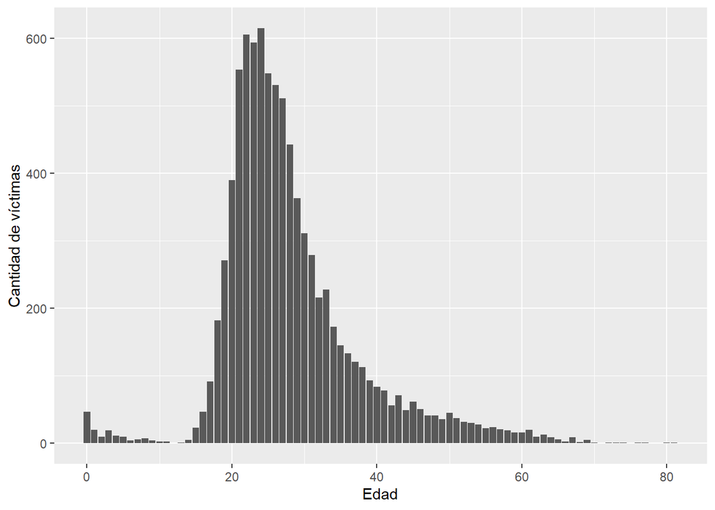

```r
victimas_denuncia %>%
  group_by(edad_al_momento_del_hecho_numerico) %>%
  summarise(cantidad = n()) %>%
  arrange(desc(cantidad)) %>%
  ggplot(aes(edad_al_momento_del_hecho_numerico, cantidad)) +
  geom_col() +
  labs(x = "Edad", y = "Cantidad de víctimas")
```

Buscamos el promedio, el valor máximo, el valor mínimo y el desvío estándar de la edad.

```r
victimas_denuncia %>%
  summarise(edad_max = max(edad_al_momento_del_hecho_numerico, na.rm = TRUE),
            edad_min = min(edad_al_momento_del_hecho_numerico, na.rm = TRUE),
            edad_media = mean(edad_al_momento_del_hecho_numerico, na.rm = TRUE),
            edad_sd = sd(edad_al_momento_del_hecho_numerico, na.rm = TRUE)) %>%
  rename("Edad máxima" = edad_max,
         "Edad mínima" = edad_min,
         "Edad media" = edad_media,
         "Desviación estándar" = edad_sd)
```

```
##   Edad máxima Edad mínima Edad media Desviación estándar
## 1          81           0   28.08264            9.549192
```

## Aclaración importante antes de continuar

Es necesario mencionar una cuestión muy importante sobre este trabajo, y es que, más allá de que los datos recabados indican un número de 8751 víctimas, existe una gran cantidad de víctimas desaparecidas que aún no han sido encontradas y cuya búsqueda continúa hasta el día de hoy.

## Hipótesis

La mayor cantidad de secuestros y/o asesinatos de víctimas ocurrieron entre los años 1976 y 1977 y el rango etario predominante de las víctimas fue de 20 a 30 años. Esto nos hace reflexionar sobre si la edad universitaria fue un factor a la hora de convertirse en posibles víctimas.

En el presente trabajo intentaremos responder, estableciendo las relaciones entre distintas variables. La hipótesis planteada es que la mayoría de los desaparecidos eran estudiantes universitarios. En caso de refutarse esta hipótesis, analizaremos cuál es la variable identitaria predominante en las víctimas del terrorismo de Estado de la última dictadura cívico-militar.

## Blanco sobre negro

Lo primero que queremos conocer es en qué años se produjeron los asesinatos y/o secuestros.

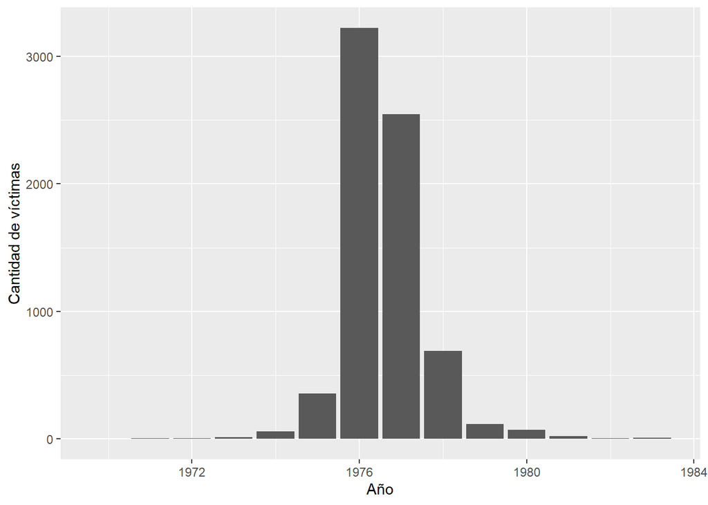

```r
victimas_parque %>%
  group_by(fecha_de_secuestro) %>%
  mutate(fecha = dmy(fecha_de_secuestro)) %>%
  mutate(anio = year(fecha)) %>%
  group_by(anio) %>%
  summarise(victimas_por_anio = n()) %>%
  arrange(desc(victimas_por_anio)) %>%
  ggplot(aes(anio, victimas_por_anio)) +
  geom_col() +
  labs(x = "Año", y = "Cantidad de víctimas")
```

Tomamos la decisión de tomar los años 1976 y 1977 porque estos años contienen la mayoría de los casos, lo que nos permitirá entender las características identitarias de las víctimas.

Edad de las víctimas

Año 1976

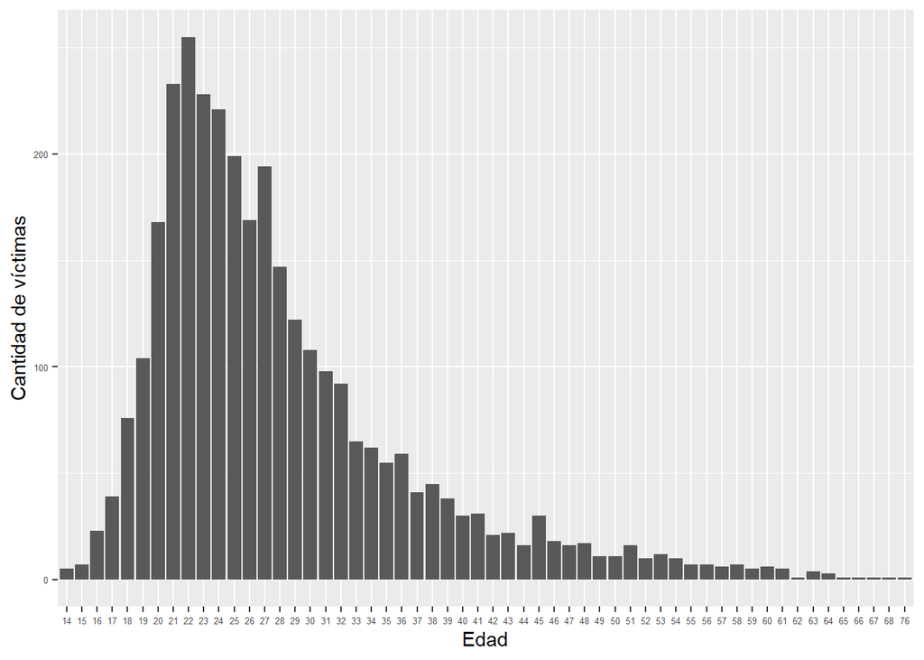

```r
victimas_parque %>%
  group_by(fecha_de_secuestro) %>%
  mutate(fecha = dmy(fecha_de_secuestro)) %>%
  mutate(anio = year(fecha)) %>%
  group_by(anio, edad) %>%
  filter(!is.na(anio) & anio == 1976) %>%
  filter("-" != edad) %>%
  summarise(victimas_por_anio = n()) %>%
  arrange(desc(victimas_por_anio)) %>%
  ggplot(aes(edad, victimas_por_anio)) +
  geom_col() +
  labs(x = "Edad", y = "Cantidad de víctimas") +
  theme(axis.text = element_text(size = 5))
```

Año 1977

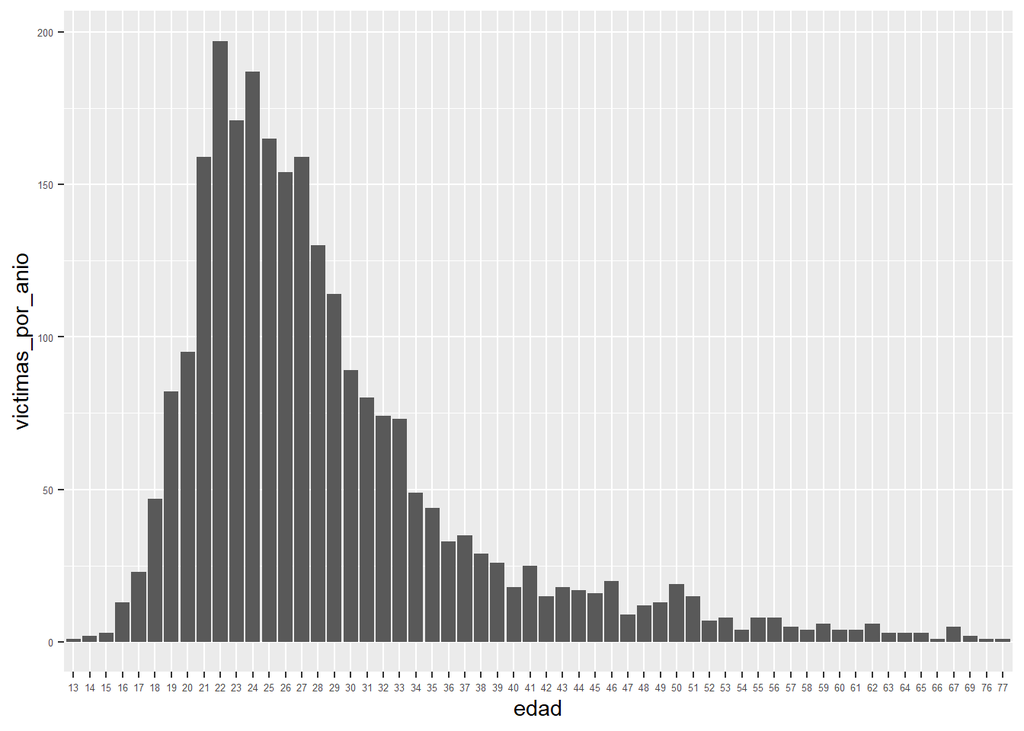

```r
victimas_parque %>%
  group_by(fecha_de_secuestro) %>%
  mutate(fecha = dmy(fecha_de_secuestro)) %>%
  mutate(anio = year(fecha)) %>%
  group_by(anio, edad) %>%
  filter(!is.na(anio) & anio == 1977) %>%
  filter("-" != edad) %>%
  summarise(victimas_por_anio = n()) %>%
  arrange(desc(victimas_por_anio)) %>%
  ggplot(aes(edad, victimas_por_anio)) +
  geom_col() +
  theme(axis.text = element_text(size = 5))
```

Creamos dataset de victimas por edad y ocupacion entre 1976 y 1982.

```r
victimas_76_82 <- victimas_parque %>%
  group_by(fecha_de_secuestro) %>%
  mutate(fecha = dmy(fecha_de_secuestro)) %>%
  mutate(anio = year(fecha)) %>%
  group_by(anio, ocupaciones, edad) %>%
  filter(anio %in% c(1976:1982)) %>%
  summarise(victimas_por_anio = n()) %>%
  arrange(desc(anio))
```

```r
victimas_76_82 %>%
  group_by(anio) %>%
  summarise(cantidad_victimas = n()) %>%
  summarise(suma = sum(cantidad_victimas)) %>%
  rename("Cantidad de víctimas" = suma) %>%
  gt::gt()
```

| Cantidad de víctimas |
| --- |
| 4276 |

También nos preguntamos cómo varió la edad de las víctimas entre los años 1976 y 1982. Si disminuyó el número de secuestros y/o asesinatos, pensar en posibles respuestas que indiquen esta característica.

Edad de las víctimas desde 1976 a 1982.

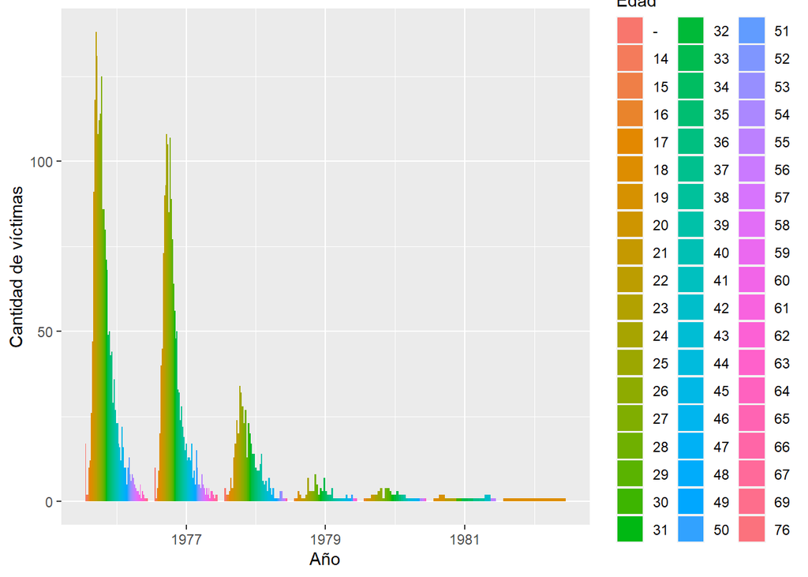

```r
victimas_76_82 %>%
  filter(!is.na(ocupaciones)) %>%
  group_by(edad, anio) %>%
  summarise(victimas_por_anio = n()) %>%
  arrange(desc(victimas_por_anio)) %>%
  ggplot(aes(anio, victimas_por_anio)) +
  geom_col(aes(fill = edad), position = "dodge") +
  labs(x = "Año", y = "Cantidad de víctimas", fill = "Edad")
```

Se observa en gamas verdes y naranjas, lo que indica que el rango etario predominante es entre los 20 y 30 años.

¿Cuál es la proporción de militantes cuyas ocupaciones están vinculadas a estudios y cuál vinculadas a la actividad sindical? Queremos establecer relaciones entre estas variables y los lugares de secuestro y/o asesinato de las víctimas.

## Proporción de ocupaciones

```r
ocupaciones <- victimas_76_82 %>%
  mutate(ocupaciones = case_when(
  stringr::str_detect(ocupaciones, "Est") ~ "Estudiante",
  stringr::str_detect(ocupaciones, "est") ~ "Estudiante",
  is.na(ocupaciones)                      ~ as.character(NA)))
```

Introducimos la proporción de estudiantes sobre la cantidad total de víctimas desde 1976 hasta 1982.

```r
ocupaciones %>%
  group_by(ocupaciones) %>%
  summarise(n = n()) %>%
  mutate(prop = n/sum(n)) %>%
  mutate(prop = scales::percent(prop)) %>%
  rename("Ocupaciones" = ocupaciones, "Cantidad" = n, "Proporción" = prop) %>%
  gt::gt()
```

| Ocupaciones | Cantidad | Proporción |
| --- | --- | --- |
| Estudiante | 1147 | 27% |
| NA | 3129 | 73% |

Procedemos a visualizarlo mediante un gráfico, a lo largo del golpe cívico militar.

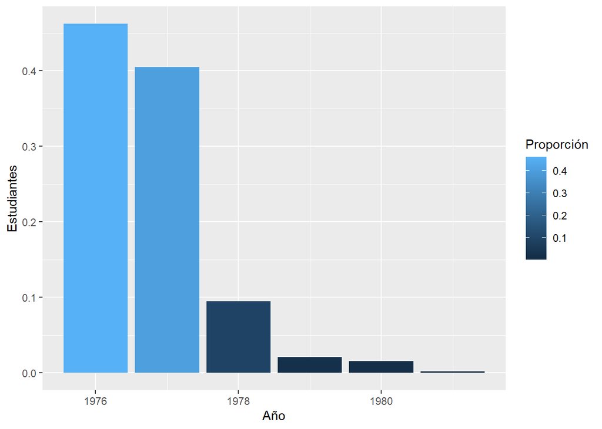

```r
ocupaciones %>%
  group_by(ocupaciones, anio) %>%
  filter(ocupaciones == "Estudiante") %>%
  summarise(n = n()) %>%
  mutate(prop = n/sum(n)) %>%
  ggplot(aes(anio, prop)) +
  geom_col(aes(fill = prop)) +
  labs(x = "Año", y = "Estudiantes", fill = "Proporción")
```

Comparamos la proporción de estudiantes con el total de otras ocupaciones.

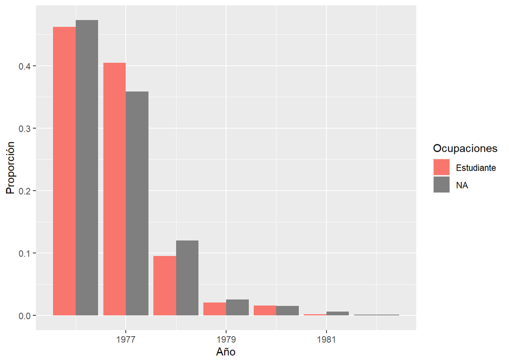

```r
ocupaciones %>%
  group_by(ocupaciones, anio) %>%
  summarise(n = n()) %>%
  mutate(prop = n/sum(n)) %>%
  ggplot(aes(anio, prop)) +
  geom_col(aes(fill = ocupaciones), position = "dodge") +
  labs(x = "Año", y = "Proporción", fill = "Ocupaciones" )
```

**Debajo intentamos demostrar la proporción de ocupaciones de las víctimas durante el período 1976-1982. No dan los mismos números que arriba porque utilizamos case when para encontrar todas las víctimas que además de tener una ocupación laboral, eran estudiantes. Por ejemplo “empleada estudiante derecho”

```r
victimas_parque %>%
  group_by(fecha_de_secuestro) %>%
  mutate(fecha = dmy(fecha_de_secuestro)) %>%
  mutate(anio = year(fecha)) %>%
  filter(anio %in% c(1976:1982)) %>%
  group_by(ocupaciones) %>%
  filter(!is.na(ocupaciones)) %>%
  summarise(proporcion_ocupacion = n()/nrow(.)) %>%
  arrange(desc(proporcion_ocupacion)) %>%
  mutate(proporcion_ocupacion = scales::percent(proporcion_ocupacion)) %>%
  head(50)
```

```
## # A tibble: 50 × 2
##    ocupaciones              proporcion_ocupacion
##    <chr>                    <chr>
##  1 Estudiante Universitario 9.063%
##  2 Estudiante Universitaria 5.563%
##  3 Estudiante               1.881%
##  4 Estudiante Secundario    1.740%
##  5 Comerciante              1.517%
##  6 Abogado                  0.971%
##  7 Albañil                  0.890%
##  8 Obrero                   0.769%
##  9 Jornalero                0.728%
## 10 Empleado                 0.506%
## # … with 40 more rows
```

Si bien los estudiantes agrupan una gran cantidad de víctimas, parece ser que no corrobora nuestra hipótesis. Agrupando por edad, por año, posee mayor número de víctimas en conjunto que las demás ocupaciones. Lo que resulta de este análisis es que si bien es una variable identitaria representativa, no es la única y no necesariamente la edad universitaria fue un factor a la hora de convertirse en posibles víctimas.

## Si no fue la edad, ¿entonces, qué?

Las primeras cinco ciudades con más desaparecidos son Capital Federal, Córdoba Capital, La Plata, San Miguel de Tucumán, Rosario y, en un sexto lugar y con más de 180 casos, aparece Mar del Plata. Esto resulta, como mínimo, interesante ya que Mar del Plata no se presenta como una ciudad universitaria. ¿La variable estudiantes explicaba también los casos ocurridos en las otras cinco ciudades? Debemos incorporar otras categorías al análisis, como son los espacios de militancia. ¿Cuál es la proporción de militantes cuyas ocupaciones están vinculadas a estudios y cuál vinculadas a la actividad sindical? Y establecer relaciones entre estas variables y los lugares de secuestro y/o asesinato de las víctimas.

Dicho lo anterior, nuestra hipótesis se pregunta cuál fue la variable identitaria que más se repite en las víctimas y cuál es su relación con el lugar del hecho y el año en que ocurrieron.

```r
militancia_sindical <- militancias %>%
  group_by(edad, fecha_de_secuestro, orga1, orga2, orga3, orga4) %>%
  summarise(cant_por_militancia = n()) %>%
  arrange(desc(cant_por_militancia))
```

Realizamos un filtro para poder identificar a les sindicalistes por ciudad.

```r
filtro_ms <- militancia_sindical %>%
  group_by(fecha_de_secuestro) %>%
  mutate(fecha = dmy(fecha_de_secuestro)) %>%
  mutate(anio = year(fecha)) %>%
  group_by(edad, anio, orga1) %>%
  summarise(cant_por_militancia = n()) %>%
  arrange(desc(cant_por_militancia)) %>%
  mutate(sindicato = case_when(
  stringr::str_detect(orga1, "Sind") ~ "sindicalista",
  stringr::str_detect(orga1, "sind") ~ "sindicalista",
  stringr::str_detect(orga1, "Delega") ~ "sindicalista",
  stringr::str_detect(orga1, "delega") ~ "sindicalista",
  stringr::str_detect(orga1, "ATE") ~ "sindicalista",
  stringr::str_detect(orga1, "UOCRA") ~ "sindicalista",
  stringr::str_detect(orga1, "Obrer") ~ "sindicalista",
  stringr::str_detect(orga1, "obrer") ~ "sindicalista",
  stringr::str_detect(orga1, "Trab") ~ "sindicalista",
  stringr::str_detect(orga1, "trab") ~ "sindicalista",
  stringr::str_detect(orga1, "UOM") ~ "sindicalista",
  stringr::str_detect(orga1, "CGT") ~ "sindicalista",
  stringr::str_detect(orga1, "UTA") ~ "sindicalista",
  stringr::str_detect(orga1, "UPCN") ~ "sindicalista",
  stringr::str_detect(orga1, "Grem") ~ "sindicalista",
  stringr::str_detect(orga1, "grem") ~ "sindicalista"))
```

```r
filtro_ms %>%
  filter(anio %in% c(1976:1982)) %>%
  group_by(anio, orga1, sindicato) %>%
  filter(sindicato == "sindicalista") %>%
  summarise(n = n()) %>%
  arrange(desc(n))
```

```
## # A tibble: 204 × 4
## # Groups:   anio, orga1 [204]
##     anio orga1                                            sindicato        n
##    <dbl> <chr>                                            <chr>        <int>
##  1  1976 Partido Revolucionario de los Trabajadores       sindicalista    29
##  2  1976 Militante sindical                               sindicalista    28
##  3  1977 Partido Revolucionario de los Trabajadores       sindicalista    25
##  4  1976 Partido Revolucionario de los Trabajadores (PRT) sindicalista    23
##  5  1976 Partido Socialista de los Trabajadores (PST)     sindicalista    20
##  6  1977 Militante sindical                               sindicalista    20
##  7  1977 Partido Revolucionario de los Trabajadores (PRT) sindicalista    18
##  8  1977 Partido Socialista de los Trabajadores (PST)     sindicalista    17
##  9  1977 Juventud de Trabajadores Peronistas (JTP)        sindicalista    15
## 10  1976 Organización Comunista Poder Obrero (OCPO)       sindicalista    14
## # … with 194 more rows
```

Cantidad de víctimas con actividad sindical

```r
filtro_ms %>%
  filter(anio %in% c(1976:1982)) %>%
  group_by(sindicato) %>%
  filter(sindicato == "sindicalista") %>%
  summarise(n = n()) %>%
  rename("Tipo de espacio de militancia" = sindicato, "Cantidad de víctimas" = n )
```

```
## # A tibble: 1 × 2
##   `Tipo de espacio de militancia` `Cantidad de víctimas`
##   <chr>                                            <int>
## 1 sindicalista                                       527
```

Víctimas con espacios de militancia partidaria.

```r
filtro_ms %>%
  filter(anio %in% c(1976:1982)) %>%
  filter(is.na(sindicato)) %>%
  group_by(orga1, sindicato) %>%
  summarise(n = n()) %>%
  arrange(desc(n))
```

```
## # A tibble: 173 × 3
## # Groups:   orga1 [173]
##    orga1                                       sindicato     n
##    <chr>                                       <chr>     <int>
##  1 Montoneros                                  <NA>        116
##  2 Juventud Peronista (JP)                     <NA>         73
##  3 Partido Comunista (PC)                      <NA>         55
##  4 Partido Comunista Marxista Leninista (PCML) <NA>         46
##  5 Ejército Revolucionario del Pueblo (ERP)    <NA>         39
##  6 Juventud Universitaria Peronista (JUP)      <NA>         39
##  7 Peronista                                   <NA>         36
##  8 Partido Justicialista (PJ)                  <NA>         33
##  9 Vanguardia Comunista (VC)                   <NA>         30
## 10 Juventud Guevarista (JG)                    <NA>         22
## # … with 163 more rows
```

## Acercándonos al final

```r
militancia_lugar_secuestro <- militancias %>%
  group_by(edad, fecha_de_secuestro, orga1, orga2, orga3, orga4, lugar_de_secuestro) %>%
  summarise(cant_por_militancia = n()) %>%
  arrange(desc(cant_por_militancia))
```

```r
filtro_lugar <- militancia_lugar_secuestro %>%
  group_by(fecha_de_secuestro) %>%
  mutate(fecha = dmy(fecha_de_secuestro)) %>%
  mutate(anio = year(fecha)) %>%
  group_by( anio, orga1, lugar_de_secuestro) %>%
  summarise(cant_por_militancia = n()) %>%
  arrange(desc(cant_por_militancia)) %>%
  mutate(sindicato = case_when(
  stringr::str_detect(orga1, "Sind") ~ "sindicalista",
  stringr::str_detect(orga1, "sind") ~ "sindicalista",
  stringr::str_detect(orga1, "Delega") ~ "sindicalista",
  stringr::str_detect(orga1, "delega") ~ "sindicalista",
  stringr::str_detect(orga1, "ATE") ~ "sindicalista",
  stringr::str_detect(orga1, "UOCRA") ~ "sindicalista",
  stringr::str_detect(orga1, "Obrer") ~ "sindicalista",
  stringr::str_detect(orga1, "obrer") ~ "sindicalista",
  stringr::str_detect(orga1, "Trab") ~ "sindicalista",
  stringr::str_detect(orga1, "trab") ~ "sindicalista",
  stringr::str_detect(orga1, "UOM") ~ "sindicalista",
  stringr::str_detect(orga1, "CGT") ~ "sindicalista",
  stringr::str_detect(orga1, "UTA") ~ "sindicalista",
  stringr::str_detect(orga1, "UPCN") ~ "sindicalista",
  stringr::str_detect(orga1, "Grem") ~ "sindicalista",
  stringr::str_detect(orga1, "grem") ~ "sindicalista"))
```

Sindicalistas en Mar del Plata del 76 al 82

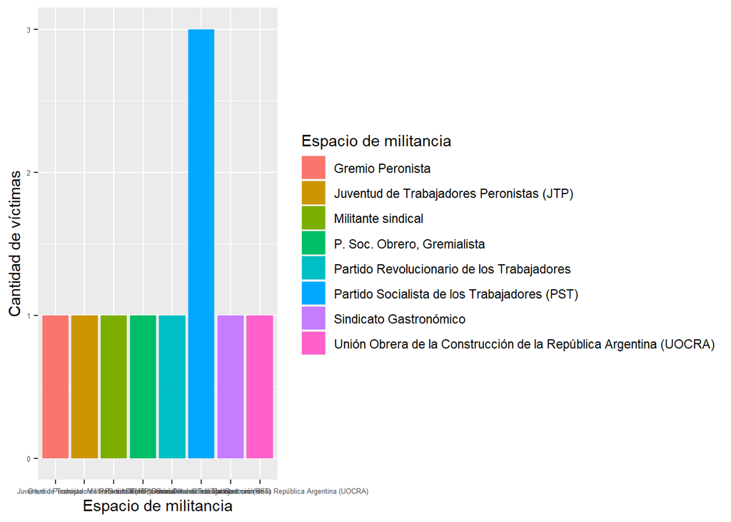

```r
filtro_lugar %>%
  filter(anio %in% c(1976:1982)) %>%
  filter(lugar_de_secuestro == "MAR DEL PLATA. BS. AS.") %>%
  group_by(lugar_de_secuestro, orga1, sindicato) %>%
  filter(sindicato == "sindicalista") %>%
  summarise(n = n()) %>%
  arrange(desc(n)) %>%
  ggplot(aes(orga1, n)) +
  geom_col(aes(fill = orga1)) +
  labs(x = "Espacio de militancia", y = "Cantidad de víctimas", fill = "Espacio de militancia") +
  theme(axis.text = element_text(size = 5))
```

Sindicalistas en Tucumán del 76 al 82

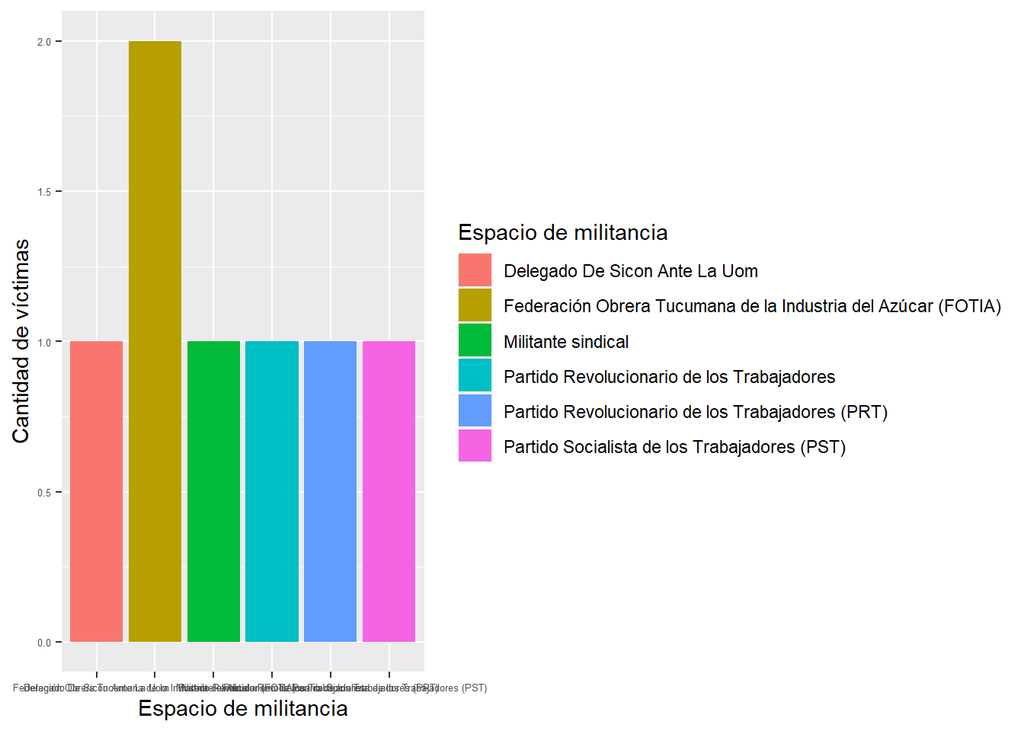

```r
filtro_lugar %>%
  filter(anio %in% c(1976:1982)) %>%
  filter(lugar_de_secuestro == "SAN MIGUEL DE TUCUMAN") %>%
  group_by(lugar_de_secuestro, orga1, sindicato) %>%
  filter(sindicato == "sindicalista") %>%
  summarise(n = n()) %>%
  arrange(desc(n)) %>%
  head(10) %>%
  ggplot(aes(orga1, n)) +
  geom_col(aes(fill = orga1)) +
  labs(x = "Espacio de militancia", y = "Cantidad de víctimas", fill = "Espacio de militancia") +
  theme(axis.text = element_text(size = 5))
```

Sindicalistas en Capital Federal del 76 al 82

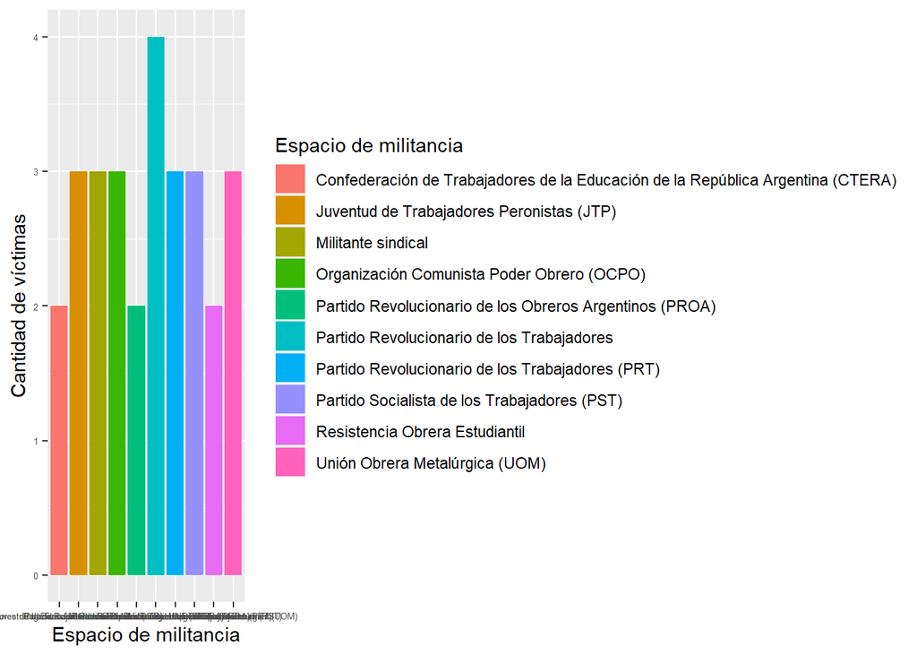

```r
filtro_lugar %>%
  filter(anio %in% c(1976:1982)) %>%
  filter(lugar_de_secuestro == "CAPITAL FEDERAL") %>%
  group_by(lugar_de_secuestro, orga1, sindicato) %>%
  filter(sindicato == "sindicalista") %>%
  summarise(n = n()) %>%
  arrange(desc(n)) %>%
  head(10) %>%
  ggplot(aes(orga1, n)) +
  geom_col(aes(fill = orga1)) +
  labs(x = "Espacio de militancia", y = "Cantidad de víctimas", fill = "Espacio de militancia") +
  theme(axis.text = element_text(size = 5))
```

Sindicalistas en Córdoba Capital del 76 al 82

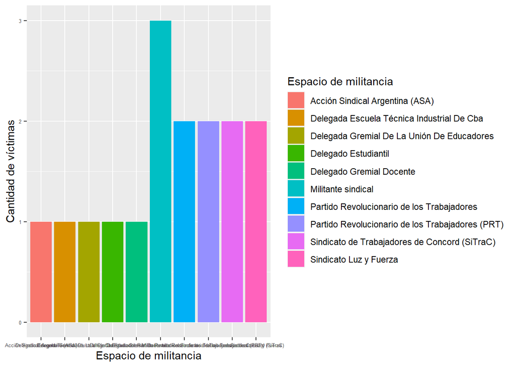

```r
filtro_lugar %>%
  filter(anio %in% c(1976:1982)) %>%
  filter(lugar_de_secuestro == "CORDOBA CAPITAL") %>%
  group_by(lugar_de_secuestro, orga1, sindicato) %>%
  filter(sindicato == "sindicalista") %>%
  summarise(n = n()) %>%
  arrange(desc(n)) %>%
  head(10) %>%
  ggplot(aes(orga1, n)) +
  geom_col(aes(fill = orga1)) +
  labs(x = "Espacio de militancia", y = "Cantidad de víctimas", fill = "Espacio de militancia") +
  theme(axis.text = element_text(size = 5))
```

Sindicalistas en Rosario del 76 al 82

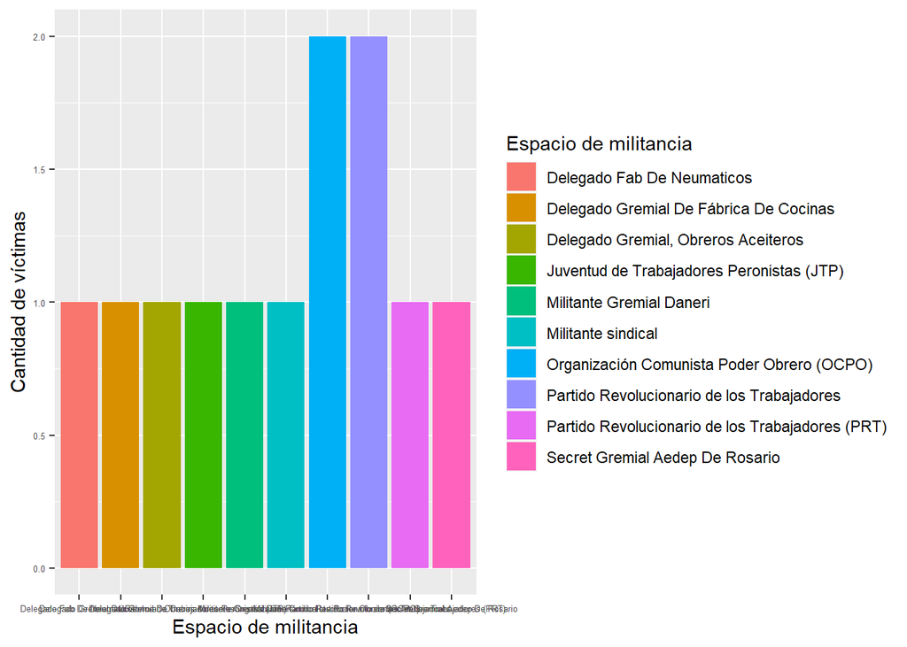

```r
filtro_lugar %>%
  filter(anio %in% c(1976:1982)) %>%
  filter(lugar_de_secuestro == "ROSARIO. SANTA FE") %>%
  group_by(lugar_de_secuestro, orga1, sindicato) %>%
  filter(sindicato == "sindicalista") %>%
  summarise(n = n()) %>%
  arrange(desc(n)) %>%
  head(10) %>%
  ggplot(aes(orga1, n)) +
  geom_col(aes(fill = orga1)) +
  labs(x = "Espacio de militancia", y = "Cantidad de víctimas", fill = "Espacio de militancia") +
  theme(axis.text = element_text(size = 5))
```

## Conclusión finales

La edad, si bien es una variable identitaria muy fuerte, parece no explicar la mayoría de los asesinatos y/o secuestros durante la última dictadura.

Refutada nuestra hipótesis, debíamos ahora encontrar una respuesta nuestro interrogante de cuál era la variable identitaria predominante entre las víctimas.

Buscamos por sindicatos y no. Los sindicatos tampoco fueron un factor que esté presente en la mayoría de los casos.

Tiene sentido, teniendo en cuenta que el plan de la última dictadura militar se centró en romper los lazos construidos por la sociedad, atacando todas las formas de organización política.

```r
 militancias %>%
  group_by(orga1) %>%
  summarise(cant_por_militancia = n()) %>%
  arrange(desc(cant_por_militancia)) %>%
  head(20) %>%
  rename("Espacio de militancia" = orga1, "Cantidad de víctimas" = cant_por_militancia) %>%
  gt::gt()
```

| Espacio de militancia | Cantidad de víctimas |
| --- | --- |
| Montoneros | 903 |
| Partido Revolucionario de los Trabajadores | 433 |
| Juventud Peronista (JP) | 396 |
| Juventud Universitaria Peronista (JUP) | 278 |
| Militante sindical | 182 |
| Partido Comunista Marxista Leninista (PCML) | 133 |
| Partido Revolucionario de los Trabajadores (PRT) | 129 |
| Ejército Revolucionario del Pueblo (ERP) | 108 |
| Partido Comunista (PC) | 105 |
| Partido Socialista de los Trabajadores (PST) | 99 |
| Unión de Estudiantes Secundarios (UES) | 95 |
| Peronista | 70 |
| Organización Comunista Poder Obrero (OCPO) | 66 |
| Juventud Guevarista (JG) | 64 |
| Juventud de Trabajadores Peronistas (JTP) | 59 |
| Partido Justicialista (PJ) | 52 |
| Vanguardia Comunista (VC) | 44 |
| Federación Juvenil Comunista (FJC) | 40 |
| Partido por la Victoria del Pueblo | 30 |
| Movimiento de Izquierda Revolucionaria | 25 |